# Assignment 2

#### 5. t-SNE for Visualization

T-Distributed Stochastic Neighbor Embedding, is a dimensionality reduction technique used for visualizing high-dimensional data in lower-dimensional spaces. It can capture non-linear relations, making it better than PCA in cases where features have a more complex relationship with each other. I used it to create a 2D representation of our dataset (hence n_components = 2 in the dataset, tho for outlier detection purposes one could argue that a higher dimension is also applicable, even tho the visualization will suffer). To counteract this I chose a high perplexity and high number of iterations, to give ample chance for a good dimensional reduction. I then calculate the Euclidean distances between points int this 2D space to help me find potential outliers (since they are too far from other datapoints). Those who are in the top 5% distance-wise are considered outliers. If we take a look at the resulting plot we can see that our method was quite effective at discovering outliers, most points labeled as such are visible far from the 2D projections of others.

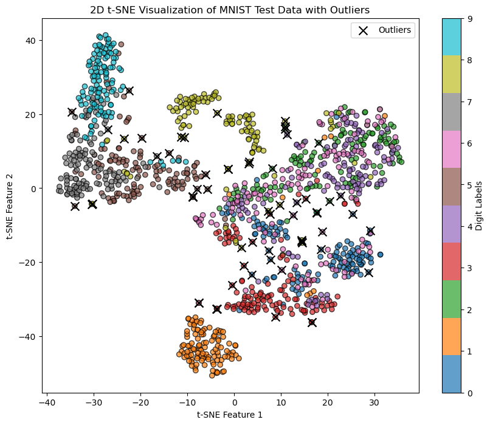

```python
from sklearn.manifold import TSNE

tsne = TSNE(n_components=2,
            perplexity=40,
            n_iter=10000, random_state=42)

X_tsne = tsne.fit_transform(X)  # Using a subset for quicker execution



# Outlier Detection: Calculate the distance from each point to its neighbors
distances = np.sqrt(((X_tsne[:, np.newaxis, :] - X_tsne[np.newaxis, :, :]) ** 2).sum(axis=2)) # computes the distance between each pair
k_nearest_distances = np.sort(distances, axis=1)[:, 1:6]  # selects the distances to the five nearest points (excluding the distance to the point itself, which is zero).
outlier_scores = k_nearest_distances.mean(axis=1) #The mean distance to these nearest point
outliers = outlier_scores > np.percentile(outlier_scores, 95)  # Top 5% as outliers

# 2D Visualization of t-SNE results with Outliers
plt.figure(figsize=(10, 8))
scatter = plt.scatter(X_tsne[:, 0], X_tsne[:, 1], c=labels,
            cmap='tab10',
            edgecolor='k', alpha=0.7)
plt.scatter(X_tsne[outliers, 0], X_tsne[outliers, 1], c='k', marker='x', s=100, label='Outliers')
plt.title('2D t-SNE Visualization of MNIST Test Data with Outliers')
plt.xlabel('t-SNE Feature 1')
plt.ylabel('t-SNE Feature 2')
plt.colorbar(scatter, label='Digit Labels')
plt.legend()
plt.show()
```

#### 6. Comparative Analysis

A rather simple way of making sure that our methods are effective is to take a look at the pictures it considered as outliers. In this instance however it is quite futile, all pictures contain cloths, and if we are not up to date with the collections of MNIST we have are unable to judge whether our models were right or wrong. PCA captures the principal components of the data, making it effective for identifying variations along major axes. The problem is that it can only be applied in cases where there is a linear relation between features, but it is quite effective when outliers contribute significantly to variance. It is also hard to interpret it. t-SNE-based Outlier Detection is effective at capturing non-linear relationships in high-dimensional data making it suitable for datasets with complex structures. Just like PCA it makes for a clear visualization as well. Its stochastic nature however is a disadvantage as well as the fact that we have to tune it, meaning it needs a lot more effort. With auto encoders reconstruction loss provides a quantitative measure for identifying outliers. It is also effective when used on non-linear relationships as it is capable of capturing their complexities. It can be very computationally expensive on the other hand, since it is basically a neural network, and it depends highly on the hyperparameters as well. It is hard to visualize and is stochastic in nature.

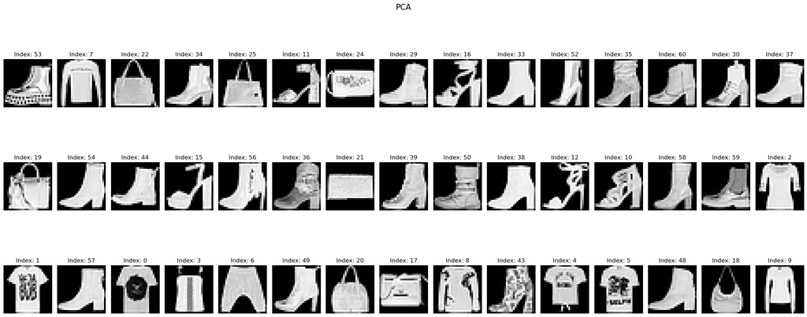

```python
img = X[outliers_pca ]
indx = np.random.choice(range(img.shape[0]) , 45, replace =False)
plt.figure(figsize=(23, 10))
for i, idx in enumerate(indx):
    plt.subplot(3, 15, i + 1)
    plt.imshow(img[idx].reshape(28,28), cmap='gray')
    plt.title(f"Index: {idx}")
    plt.axis('off')
plt.tight_layout()
plt.suptitle('PCA', fontsize=16, y=1.02)
plt.show()
```

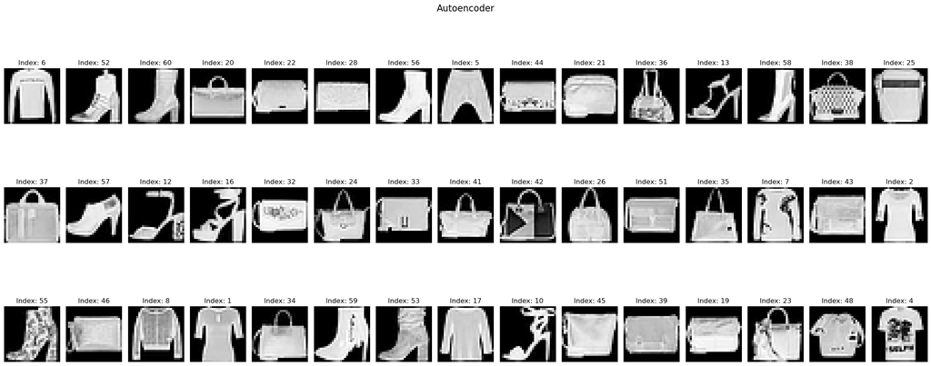

```python
img = X[outliers_autoencoder]
indx = np.random.choice(range(img.shape[0]) , 45, replace =False)
plt.figure(figsize=(23, 10))
for i, idx in enumerate(indx):
    plt.subplot(3, 15, i + 1)
    plt.imshow(img[idx].reshape(28,28), cmap='gray')
    plt.title(f"Index: {idx}")
    plt.axis('off')
plt.tight_layout()
plt.suptitle('Autoencoder', fontsize=16, y=1.02)
plt.show()
```

[figure not shown]

```python
img = X[outliers]
indx = np.random.choice(range(img.shape[0]) , 45, replace =False)
plt.figure(figsize=(23, 10))
for i, idx in enumerate(indx):
    plt.subplot(3, 15, i + 1)
    plt.imshow(img[idx].reshape(28,28), cmap='gray')
    plt.title(f"Index: {idx}")
    plt.axis('off')
plt.tight_layout()
plt.suptitle('t-SNE', fontsize=16, y=1.02)
plt.show()
```